# Лабораторная работа № 1

Введение в Mininet

Пакавира Арсениу Висенте Луиш

Российский университет дружбы народов, Москва, Россия

## Докладчик

- Пакавира Арсениу Висенте Луиш
- Студент
- Российский университет дружбы народов
- [1032225105@rudn.ru]

[figure not shown]

## Цель работы

Основной целью работы является развёртывание в системе виртуализации (например, в VirtualBox) mininet, знакомство с основными командами для работы с Mininet через командную строку и через графический интерфейс.

## Теоретическое введение

Mininet[@mininet] – это эмулятор компьютерной сети. Под компьютерной сетью подразумеваются простые компьютеры — хосты, коммутаторы, а так же OpenFlow-контроллеры. С помощью простейшего синтаксиса в примитивном интерпретаторе команд можно разворачивать сети из произвольного количества хостов, коммутаторов в различных топологиях и все это в рамках одной виртуальной машины(ВМ). На всех хостах можно изменять сетевую конфигурацию, пользоваться стандартными утилитами(ifconfig, ping) и даже получать доступ к терминалу. На коммутаторы можно добавлять различные правила и маршрутизировать трафик.

Mininet создает реалистичную виртуальную сеть, выполняя реальный код ядра, коммутатора и приложения на одной машине (VM, облачной или собственной) за считанные секунды с помощью одной команды `sudo mn`.

## Выполнение лабораторной работы

[figure not shown]

Настройка сети

## Выполнение лабораторной работы

[figure not shown]

Настройка сети

## Выполнение лабораторной работы

[figure not shown]

Запуск mininet

## Выполнение лабораторной работы

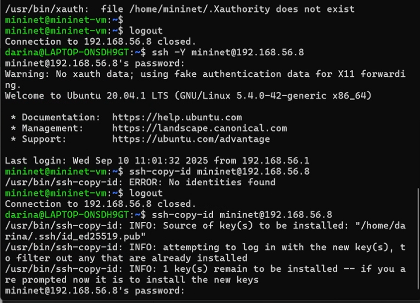

Подключение к mininet через SSH

## Выполнение лабораторной работы

[figure not shown]

Просмотр IP-адресов машины

## Выполнение лабораторной работы

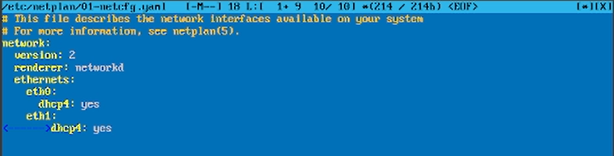

Файл /etc/netplan/01-netcfg.yaml

## Выполнение лабораторной работы

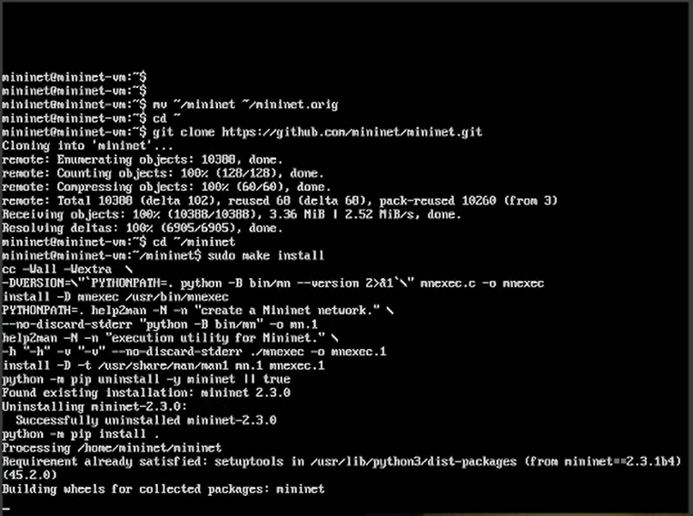

Обновление Mininet

## Выполнение лабораторной работы

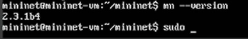

Номер установленной версии mininet

## Выполнение лабораторной работы

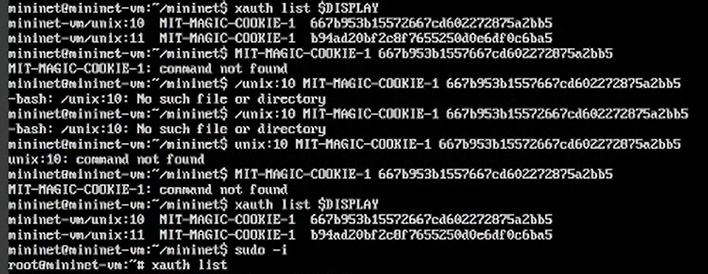

Настройка соединения X11 для суперпользователя

## Выполнение лабораторной работы

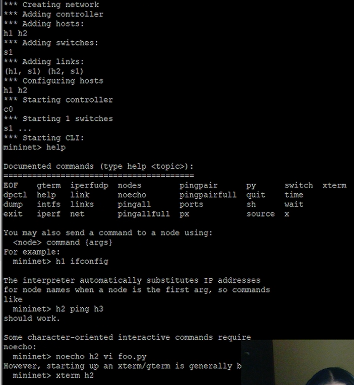

Работа с Mininet с помощью командной строки

## Выполнение лабораторной работы

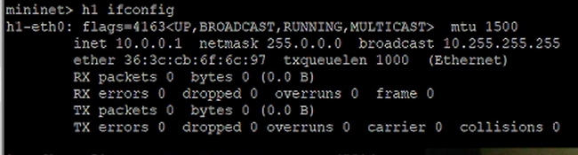

Работа с Mininet с помощью командной строки

## Выполнение лабораторной работы

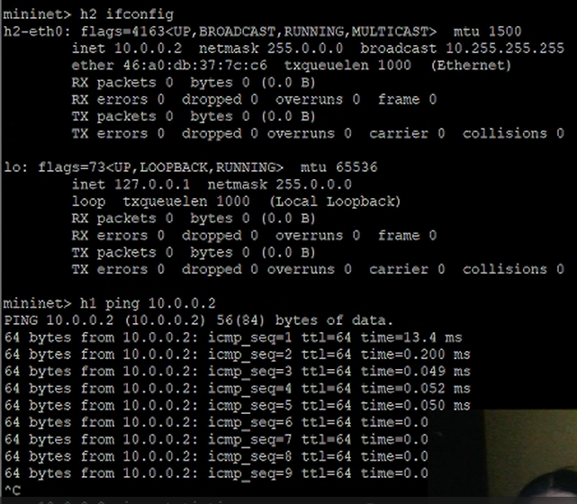

Работа с Mininet с помощью командной строки

## Выполнение лабораторной работы

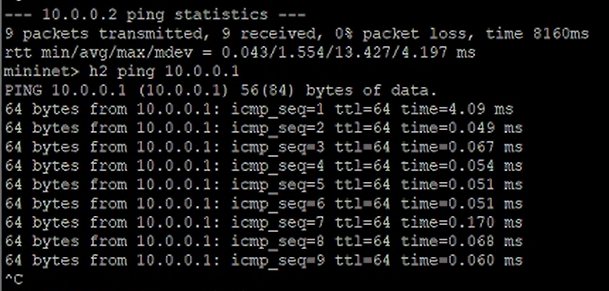

Проверка связности хостов

## Выполнение лабораторной работы

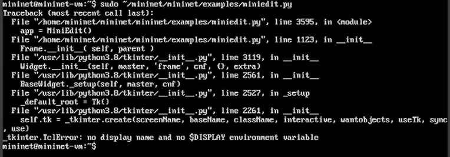

sudo ~/mininet/mininet/examples/miniedit.py

## Выполнение лабораторной работы

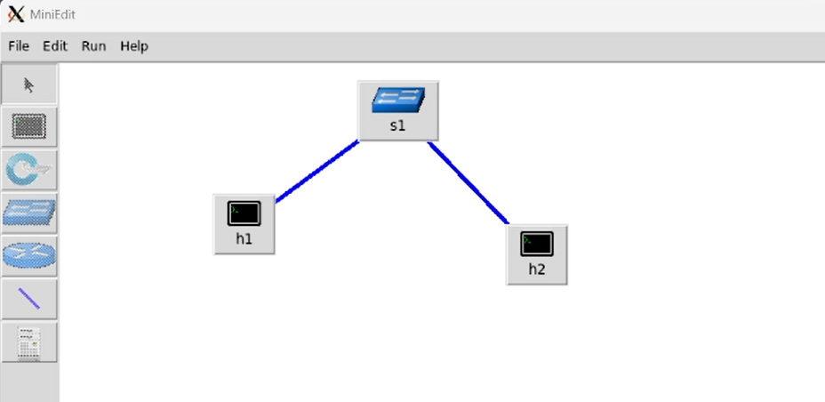

## Выводы

В результате выполнения данной лабораторной работы я развёрнул mininet в системе виртуализации VirtualBox, а также ознакомилась с основными командами для работы с Mininet через командную строку и через графический интерфейс.